# Talle corte2: Mapeando la Seguridad Vial

## Mapa de densidad (hotspots)

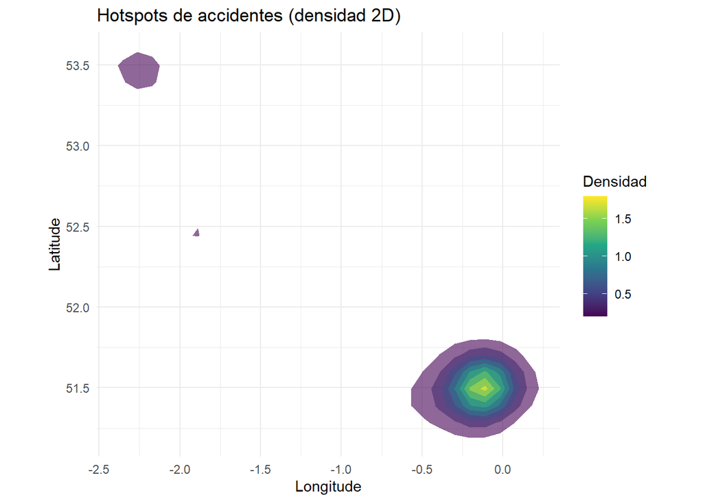

```r
ggplot(df_geo, aes(x = Longitude, y = Latitude)) +
  stat_density_2d(aes(fill = ..level..), geom = "polygon", alpha = 0.6) +
  coord_fixed() +
  scale_fill_viridis_c() +
  labs(title = "Hotspots de accidentes (densidad 2D)",
       x = "Longitude", y = "Latitude", fill = "Densidad") +
  theme_minimal()
```

# 5. Preguntas de reflexión

## ¿Por qué una correlación entre flujo de bicicletas y coches no implica causalidad? Menciona un posible factor de confusión.

### La correlación entre el tráfico de bicicletas y automóviles no implica causalidad, ya que solo muestra que ambas variables varían juntas. Un factor externo, como el entorno urbano, podría influir en ambas: las zonas urbanas suelen concentrar más bicicletas por desplazamientos y ocio, y más autos por densidad poblacional y demanda de transporte. Así, es más probable que el contexto urbano afecte a ambos tipos de tráfico, y no que uno cause al otro.

## Si tuvieras que recomendar una intervención de seguridad vial con base en tu análisis, ¿cuál sería y por qué?

### Según el mapa de densidad, las intervenciones de seguridad vial deberían centrarse en las zonas con mayor concentración de accidentes. Se recomienda mejorar la infraestructura y señalización, reforzar el control policial, aplicar medidas de moderación del tráfico y realizar campañas de concienciación sobre las causas más comunes. Enfocar los recursos en estos puntos críticos permitiría una reducción más eficiente de los accidentes.